# SDS/CSC 293 Mini-Project 5: LASSO

Group 18: Karen Santamaria, Mariama Jaiteh

Thursday, May 2<sup>nd</sup>, 2019

You will be submiting an entry to Kaggle’s [House Prices: Advanced Regression Techniques](https://www.kaggle.com/c/house-prices-advanced-regression-techniques/) by fitting a fitted spline, multiple regression LASSO regularized multiple regression model $\hat{f}(x)$.

However of the original 1460 rows of the `training` data, in the `data/` folder you are given a `train.csv` consisting of only 50 of the rows!

# Load data

Read in data provided by Kaggle for this competition. They are organized in the `data/` folder of this RStudio project:

```r
training <- read_csv("data/train.csv") %>%
  rename(
    FirstFlrSF = `1stFlrSF`,
    SecondFlrSF = `2ndFlrSF`,
    ThirdSsnPorch = `3SsnPorch`
  ) %>%
  # Fit your models to this outcome variable:
  mutate(log_SalePrice = log(SalePrice+1))

test <- read_csv("data/test.csv")%>%
  rename(
    FirstFlrSF = `1stFlrSF`,
    SecondFlrSF = `2ndFlrSF`,
    ThirdSsnPorch = `3SsnPorch`
  )
sample_submission <- read_csv("data/sample_submission.csv")

# Function that takes in a LASSO fit object and returns a "tidy" data frame of
# the beta-hat coefficients for each lambda value used in LASSO fit.
get_LASSO_coefficients <- function(LASSO_fit){
  beta_hats <- LASSO_fit %>%
    broom::tidy(return_zeros = TRUE) %>%
    select(term, estimate, lambda) %>%
    arrange(desc(lambda))
  return(beta_hats)
}



#data imputation

training.mis <- prodNA(training, noNA = 0.1)

for (i in names(training)){
  if(is.numeric(training[[i]])){
    training.mis[[i]] <- with(training, impute(training[[i]], median))
  }
}

test.mis <- prodNA(test, noNA = 0.1)

for (i in names(test)){
  if(is.numeric(test[[i]])){
    test.mis[[i]] <- with(test, impute(test[[i]], median))
  }
}
```

## Look at your data!

Always, ALWAYS, **ALWAYS** start by looking at your raw data. This gives you visual sense of what information you have to help build your predictive models. To get a full description of each variable, read the data dictionary in the `data_description.txt` file in the `data/` folder.

Note that the following code chunk has `eval = FALSE` meaning “don’t evaluate this chunk with knitting” because `.Rmd` files won’t knit if they include a `View()`:

```r
View(training)
glimpse(training)

View(test)
glimpse(test)

# Pay close attention to the variables and variable types in sample_submission.
# Your submission must match this exactly.
glimpse(sample_submission)

# Hint:
skim(training)
skim(test)
```

# Minimally viable product

Since we have already performed exploratory data analyses of this data in MP1 and MP2, let’s jump straight into the modeling. For this phase:

- Train an unregularized standard multiple regression model $\widehat{f}_1$ using **all** 36 numerical variables as predictors.

```r
# Train your model here:

# Model formula
model_formula <- "log_SalePrice ~ MSSubClass + LotFrontage + LotArea +
OverallQual + OverallCond + YearBuilt + YearRemodAdd + MasVnrArea + BsmtFinSF1 +
BsmtFinSF2 + BsmtUnfSF + TotalBsmtSF + FirstFlrSF + SecondFlrSF + LowQualFinSF +
GrLivArea + BsmtFullBath + BsmtHalfBath + FullBath + HalfBath + BedroomAbvGr +
KitchenAbvGr + TotRmsAbvGrd + Fireplaces + GarageYrBlt + GarageCars + GarageArea +
WoodDeckSF + OpenPorchSF + EnclosedPorch + ThirdSsnPorch + ScreenPorch + PoolArea +
MiscVal + MoSold + YrSold" %>%
  as.formula()
```

```r
# 1. Fit model to training data
model_1 <- lm(model_formula, data = training.mis)
```

```r
fitted_points_1 <- model_1 %>%
  broom::augment()
```

# Due diligence

- Compute two RMLSE’s of the fitted model $\widehat{f}_1$
  1. on the `training` data. You may use a function from a package to achieve this.
  2. on the `test` data via a submission to Kaggle `data/submit_regression.csv`.
- Compare the two RMLSE’s. If they are different, comment on why they might be different.

```r
# RMSLE for training data. Using MSE since we are working with log_SalePrice
rmsle_train = MLmetrics::MSE(y_pred = fitted_points_1$.fitted, y_true = fitted_points_1$log_SalePrice)
rmsle_train
```

```
## [1] 0.002258692
```

```r
predict_test <- model_1 %>%
  broom::augment(newdata = test.mis)
```

```r
#Getting RMSLE for test data
submission <- test %>%
  mutate(SalePrice = exp(predict_test$.fitted)) %>%
  select(Id, SalePrice)

write_csv(submission, path = "data/submission_due_diligence.csv")
```

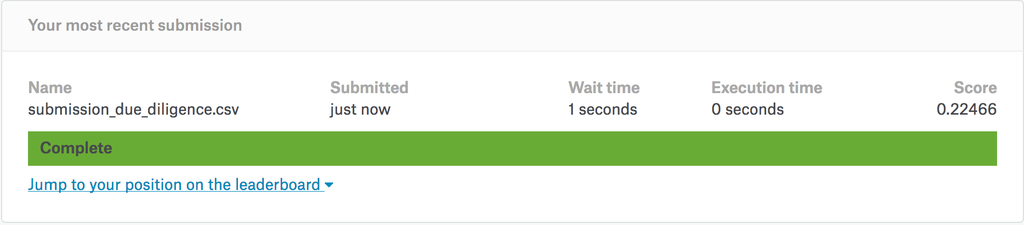

| RMLSE on training | RMLSE on test (via Kaggle) |
| --- | --- |
| 0.002258692 | 0.22466 |

The two RMLSEs are different because our training set has only 50 observations so when we fit/test the model, we notice that we are overfitting, hence why we have a lower RMLSE for training which is closer to 0. When we use our model on the full test, there are some scenarios that our model of 50 observations hasn’t seen so the model might be way off with the predicted saleprice.

# Reaching for the stars

1. Find the $\lambda^*$ tuning parameter that yields the LASSO model with the lowest estimated RMLSE as well as this lowest RMLSE as well. You may use functions included in a package for this.
2. Convince yourself with a visualization that the $\lambda^*$ you found is indeed the one that returns the lowest estimated RMLSE.
3. What is the model $\widehat{f}$_2 resulting from this $\lambda^*$? Output a data frame of the $\widehat{\beta}$.
4. Visualize the progression of $\widehat{\beta}$ for different $\lambda$ values and mark $\lambda^*$ with a vertical line:

```r
# Find lambda star:

x_matrix <- training.mis %>%
  modelr::model_matrix(model_formula, data = .) %>%
  select(-`(Intercept)`) %>%
as.matrix()


#lambda_inputs <- seq(from = 0, to = 1000)
lambda_inputs <- 10^seq(from = -5, to = 3, length = 100)

LASSO_fit <- glmnet(x = x_matrix, y = training$log_SalePrice, alpha = 1, lambda = lambda_inputs)

LASSO_CV <- cv.glmnet(
  x = x_matrix,
  y = training$log_SalePrice,
  alpha = 1,
  lambda = lambda_inputs,
  nfolds = 10,
  type.measure = "mse"
)

LASSO_CV %>%
  broom::tidy() %>%
  rename(mse = estimate) %>%
  arrange(mse)

# The lambda_star is in the top row. We can extract this lambda_star value from
# the LASSO_CV object:
lambda_star <- LASSO_CV$lambda.min
```

```r
lambda_star
```

```
## [1] 0.02056512
```

Get visualization that confirms lambda_star is best lamba

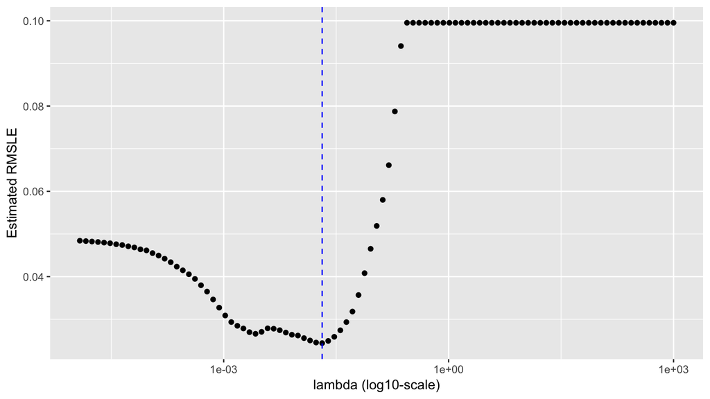

```r
LASSO_CV_df <- LASSO_CV %>%
  broom::tidy() %>%
  rename(mse = estimate) %>%
  arrange(mse)

LASSO_CV_df %>%
  ggplot(aes(x = lambda)) +
  geom_point(aes(y = mse)) +
  scale_x_log10() +
  labs(x = "lambda (log10-scale)", y = "Estimated RMSLE") +
  geom_vline(xintercept = lambda_star, linetype = "dashed", col = "blue")
```

Beta coeffiecents of best model

```r
get_LASSO_coefficients(LASSO_fit) %>%
  filter(lambda == lambda_star)
```

| term | estimate | lambda |
| --- | --- | --- |
| (Intercept) | 9.0358952 | 0.0205651 |
| MSSubClass | 0.0000000 | 0.0205651 |
| LotFrontage | 0.0002518 | 0.0205651 |
| LotArea | 0.0000150 | 0.0205651 |
| OverallQual | 0.1395618 | 0.0205651 |
| OverallCond | 0.0000000 | 0.0205651 |
| YearBuilt | 0.0009243 | 0.0205651 |
| YearRemodAdd | 0.0000000 | 0.0205651 |
| MasVnrArea | 0.0000000 | 0.0205651 |
| BsmtFinSF1 | 0.0000371 | 0.0205651 |
| BsmtFinSF2 | 0.0000000 | 0.0205651 |
| BsmtUnfSF | 0.0000000 | 0.0205651 |
| TotalBsmtSF | 0.0001172 | 0.0205651 |
| FirstFlrSF | 0.0000000 | 0.0205651 |
| SecondFlrSF | 0.0000000 | 0.0205651 |
| LowQualFinSF | 0.0000000 | 0.0205651 |
| GrLivArea | 0.0001040 | 0.0205651 |
| BsmtFullBath | 0.0000000 | 0.0205651 |
| BsmtHalfBath | 0.0000000 | 0.0205651 |
| FullBath | 0.0066641 | 0.0205651 |
| HalfBath | 0.0000000 | 0.0205651 |
| BedroomAbvGr | 0.0000000 | 0.0205651 |
| KitchenAbvGr | -0.1901792 | 0.0205651 |
| TotRmsAbvGrd | 0.0000000 | 0.0205651 |
| Fireplaces | 0.0000000 | 0.0205651 |
| GarageYrBlt | 0.0000000 | 0.0205651 |
| GarageCars | 0.0000000 | 0.0205651 |
| GarageArea | 0.0000000 | 0.0205651 |
| WoodDeckSF | 0.0000696 | 0.0205651 |
| OpenPorchSF | 0.0004938 | 0.0205651 |
| EnclosedPorch | 0.0000000 | 0.0205651 |
| ThirdSsnPorch | 0.0000000 | 0.0205651 |
| ScreenPorch | 0.0000000 | 0.0205651 |
| PoolArea | 0.0000000 | 0.0205651 |
| MiscVal | 0.0000000 | 0.0205651 |
| MoSold | 0.0000000 | 0.0205651 |
| YrSold | 0.0000000 | 0.0205651 |

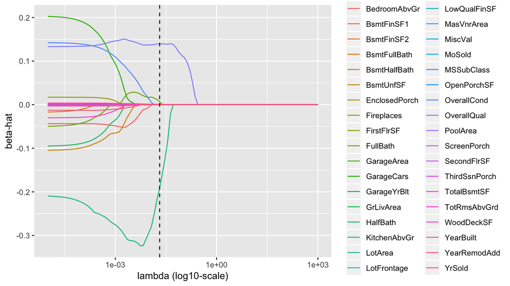

```r
# Visualize the progression of beta-hats for different lambda values and mark lambda_star with a vertical line:
LASSO_coefficients_plot <- get_LASSO_coefficients(LASSO_fit) %>%
  filter(term != "(Intercept)") %>%
  # Plot:
  ggplot(aes(x = lambda, y = estimate, col = term)) +
  geom_line() +
  labs(x = "lambda (log10-scale)", y = "beta-hat") +
  scale_x_log10()

LASSO_coefficients_plot +
  geom_vline(xintercept = lambda_star, color = "black", linetype = "dashed")
```

# Point of diminishing returns

1. In qualitative language, comment on the resulting amount of shrinkage in the LASSO model?
2. Obtain the RMLSE of the fitted model
   1. on the `training` data
   2. on the `test` data via a submission to Kaggle `data/submit_LASSO.csv` that we will test.
3. Compare the two RMLSE’s. If they are different, comment on why they might be different.

```r
# Compute both RMLSE's here:


#Get predictions from f_hat LASSO model using lambda_star
training.mis <- training.mis %>%
  mutate(y_hat_LASSO = predict(LASSO_fit, newx = x_matrix, s = lambda_star)[,1])

#RMSLE for training
rmsle_lasso = MLmetrics::MSE(y_pred = training.mis$y_hat_LASSO, y_true = training.mis$log_SalePrice)
rmsle_lasso
```

```
## [1] 0.01008322
```

```r
LASSO_fit_train <- glmnet(x = x_matrix, y = training$log_SalePrice, alpha = 1, lambda = lambda_star)


x_matrix_test <- test.mis %>%
  # Create temporary outcome variance just to get model matrix to work:
  mutate(log_SalePrice = 1) %>%
  modelr::model_matrix(model_formula, data = .) %>%
  select(-`(Intercept)`) %>%
as.matrix()

# Predict y_hat's for test data using model and same lambda = 10.
test.mis <- test.mis %>%
  mutate(y_hat_LASSO = predict(LASSO_fit_train, newx = x_matrix_test, s = 10)[,1])

submission2 <- test.mis %>%
  mutate(SalePrice = exp(test.mis$y_hat_LASSO)) %>%
  select(Id, SalePrice)

write_csv(submission2, path = "data/submit_LASSO.csv")
```

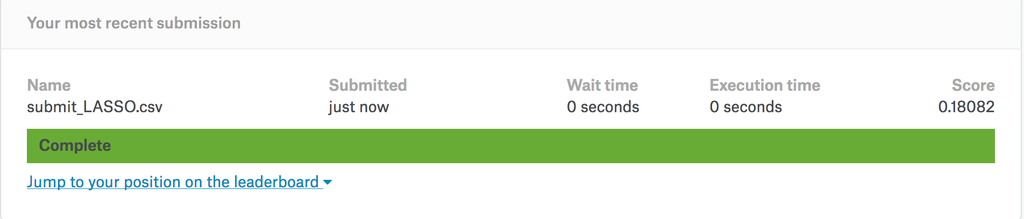

Comparing both RMLSE’s here:

| Method | RMLSE on training | RMLSE on test (via Kaggle) |
| --- | --- | --- |
| Unregularized lm | 0.002258692 | 0.22466 |
| LASSO | 0.01008322 | 0.18082 |

The LASSO model preforms better than the Unregularized model based on RMSLE values obtained from test data on Kaggle. This makes sense since with the LASSO model, the more important variables are given more weight. This seems to be because LASSO model to suffers less from overfitting which makes the training RMSLE bigger but overall, when making predictions on the test data gives better preformance.

# Polishing the cannonball

1. Fit a LASSO model $\widehat{f}_3$ that uses categorical variables as well.
2. Output a `data/submit_LASSO_2.csv`
3. Submit to Kaggle and replace the screenshot below with an screenshot of your score.
4. Try to get the best Kaggle leaderboard score!

```r
model_formula_2 <- "log_SalePrice ~ MSSubClass + LotFrontage + LotArea +
OverallQual + OverallCond + YearBuilt + YearRemodAdd + MasVnrArea + BsmtFinSF1 +
BsmtFinSF2 + BsmtUnfSF + TotalBsmtSF + FirstFlrSF + SecondFlrSF + LowQualFinSF +
GrLivArea + BsmtFullBath + BsmtHalfBath + FullBath + HalfBath + BedroomAbvGr +
KitchenAbvGr + TotRmsAbvGrd + Fireplaces + GarageYrBlt + GarageCars + GarageArea +
WoodDeckSF + OpenPorchSF + EnclosedPorch + ThirdSsnPorch + ScreenPorch + PoolArea +
MiscVal + MoSold + YrSold + HouseStyle" %>%
  as.formula()



#make matrix possible for NA values
training.mis$HouseStyle[is.na(training.mis$HouseStyle)] <- "None"
test.mis$HouseStyle[is.na(test.mis$HouseStyle)] <- "None"

training.mis$HouseStyle <- as.factor(training.mis$HouseStyle)
test.mis$HouseStyle <- as.factor(test.mis$HouseStyle)


x_matrix_2 <- training.mis %>%
  modelr::model_matrix(model_formula_2, data = .) %>%
  select(-`(Intercept)`) %>%
as.matrix()

#lambda_inputs <- seq(from = 0, to = 1000)
lambda_inputs <- 10^seq(from = -5, to = 3, length = 100)

LASSO_fit_2 <- glmnet(x = x_matrix_2, y = training$log_SalePrice, alpha = 1, lambda = lambda_inputs)


LASSO_CV_2 <- cv.glmnet(
  x = x_matrix,
  y = training$log_SalePrice,
  alpha = 1,
  lambda = lambda_inputs,
  nfolds = 10,
  type.measure = "mse"
)

LASSO_CV_2  %>%
  broom::tidy() %>%
  rename(mse = estimate) %>%
  arrange(mse)


lambda_star_2 <- LASSO_CV_2$lambda.min


#Get predictions from f_hat LASSO model using lambda_star
training.mis <- training.mis %>%
  mutate(y_hat_LASSO_2 = predict(LASSO_fit_2, newx = x_matrix_2, s = lambda_star_2)[,1])

LASSO_fit_train_2 <- glmnet(x = x_matrix_2, y = training$log_SalePrice, alpha = 1, lambda = lambda_star_2)

x_matrix_test_2 <- test.mis %>%
  # Create temporary outcome variance just to get model matrix to work:
  mutate(log_SalePrice = 1) %>%
  modelr::model_matrix(model_formula_2, data = .) %>%
  select(-`(Intercept)`) %>%
as.matrix()

# Predict y_hat's for test data using model and same lambda = 10.
test.mis <- test.mis %>%
  mutate(y_hat_LASSO_2 = predict(LASSO_fit_train_2, newx = x_matrix_test_2, s = 10)[,1])

submission3 <- test.mis %>%
  mutate(SalePrice = exp(test.mis$y_hat_LASSO_2)) %>%
  select(Id, SalePrice)

write_csv(submission3, path = "data/submit_LASSO_2.csv")
```

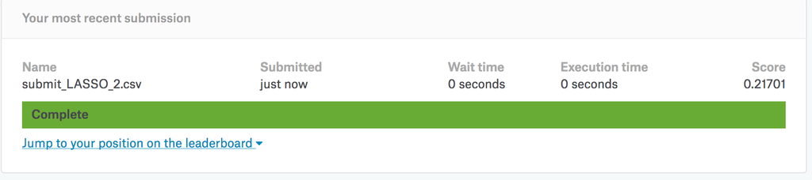